# RQ2 Step 2: Clustering districts into building markets

What kinds of building markets does New Zealand have?

while True: learn(), Group 8, STAT462

2026-11-20

```r
source(file.path(proj_root, "R", "utils_data.R"))
source(file.path(proj_root, "R", "utils_cluster.R"))
library(knitr)
library(cluster)     # silhouette, gap statistic

rq2  <- readRDS(file.path(paths$processed, "rq2_district_features.rds"))
raw  <- rq2$raw                    # natural units, for describing clusters
vars <- rq2$cluster_vars
short <- str_remove(rq2$transformed$ta, " District| City")

# standardised feature matrix: one row per district, mean 0 and SD 1 per column
X <- scale(rq2$transformed |> select(all_of(vars)))
rownames(X) <- short
D <- dist(X)                       # Euclidean distances between all pairs of districts
c(districts = nrow(X), features = ncol(X), pairs = length(D))
```

```
## districts  features     pairs
##        66         9      2145
```

# 1 Purpose and plan

Step 1 described each of the 66 districts with nine standardised features: three type-mix shares, building intensity, growth, volatility, relative cost, house size and non-residential share. Here we group districts whose profiles are similar, with two methods from the course:

- **k-means**, which divides the districts into *k* groups around *k* centres;
- **hierarchical clustering**, which builds a tree of nested groups and cuts it at *k* groups.

Clustering has no “right answer” to check against, unlike RQ1’s test set. Instead we ask:

1. How many clusters does the data support? (several criteria, section 4)
2. Do the two methods agree? (section 6)
3. Are the clusters stable when the data are resampled? (section 4)
4. Do the clusters make sense as kinds of market? (section 7)

# 2 Distance between districts

Both methods need a measure of how different two districts are. We use the **Euclidean distance** on the standardised features: the straight-line distance in nine dimensions,

$$d(a, b) = \sqrt{\textstyle\sum_{j=1}^{9} (x_{aj} - x_{bj})^2}.$$

Standardising (Step 1) gives every feature the same weight. Euclidean distance is also what k-means minimises, so using it for hierarchical clustering too keeps the two methods comparable.

```r
dm <- as.matrix(D)
diag(dm) <- NA
closest <- tibble(district = rownames(dm),
                  nearest = colnames(dm)[apply(dm, 1, which.min)],
                  distance = apply(dm, 1, min, na.rm = TRUE))
bind_rows(closest |> filter(district %in% c("Selwyn", "Wellington", "Queenstown-Lakes", "Gore", "Auckland")),
          closest |> slice_max(distance, n = 3)) |>
  distinct() |> kable(digits = 2, caption = "Nearest neighbour of some districts (and the three most isolated)")
```

Nearest neighbour of some districts (and the three most isolated)

| district | nearest | distance |
| --- | --- | --- |
| Auckland | Dunedin | 2.66 |
| Gore | Clutha | 2.36 |
| Queenstown-Lakes | Auckland | 3.91 |
| Selwyn | Waimakariri | 1.97 |
| Wellington | Dunedin | 4.00 |
| Kawerau | Waitomo | 3.50 |

**Observation.** The nearest neighbours make sense: Selwyn’s closest match is another fast-growing Canterbury or Waikato district, and Gore’s is another small southern district. The most isolated districts are the ones that stood out in the Step 1 PCA plot. They will sit at the edge of whichever cluster they join.

# 3 k-means

## 3.1 How it works

k-means looks for *k* centres (each a point in the nine-dimensional feature space) and assigns each district to its nearest centre. It repeats two steps until nothing changes:

1. **assign** every district to the closest centre;
2. **update** each centre to the mean of the districts assigned to it.

This lowers the **within-cluster sum of squares (WSS)**, the total squared distance from each district to its centre, at every step. A low WSS means tight clusters.

**Parameters of `kmeans()` and what they do:**

| Parameter | Meaning | Our choice | Effect |
| --- | --- | --- | --- |
| `centers` (*k*) | number of clusters | chosen in section 4 | the main hyperparameter: more clusters always lower WSS, so WSS alone can’t choose *k* |
| `nstart` | number of random starting centres | 50 | k-means only finds a *local* minimum that depends on the start; more starts make it more likely to find the best one |
| `iter.max` | maximum assign/update rounds | 100 | only needs to be large enough to converge; ours converge in a few rounds |
| `algorithm` | update rule | Hartigan–Wong (default) | usually finds lower WSS than the simpler Lloyd algorithm |
| seed | starting point of the random numbers | 462 | makes the result reproducible |

## 3.2 Why `nstart` matters

```r
set.seed(462)
single_start <- map_dbl(1:200, \(i) kmeans(X, centers = 3, nstart = 1)$tot.withinss)
set.seed(462)
many_start <- kmeans(X, centers = 3, nstart = 50)$tot.withinss
c(best_of_200_single = min(single_start), share_of_single_starts_at_best = mean(abs(single_start - many_start) < 1e-6),
  worst_single = max(single_start), nstart_50 = many_start)
```

```
##             best_of_200_single share_of_single_starts_at_best
##                       376.1730                         0.6500
##                   worst_single                      nstart_50
##                       409.5511                       376.1730
```

**Observation.** With a single random start, k-means reaches the best WSS in only 65% of runs; the others stop at worse local solutions (up to 410 instead of 376). With 50 starts, k-means keeps the best of the 50, so the result no longer depends on luck.

# 4 How many clusters?

The number of clusters *k* is the key hyperparameter. There is no single correct rule, so we compute five criteria for *k* = 2 to 8:

[output not shown]

```r
ks <- 2:8
set.seed(462)
criteria <- map_dfr(ks, function(k) {
  km <- kmeans(X, centers = k, nstart = 50, iter.max = 100)
  tibble(k,
         wss         = km$tot.withinss,
         silhouette  = mean_silhouette(km$cluster, D),
         ch          = calinski_harabasz(X, km$cluster),
         stability   = mean(boot_stability(X, \(x) kmeans_labels(x, k), B = 100)),
         smallest    = min(table(km$cluster)))
})

set.seed(462)
gap <- clusGap(X, FUNcluster = kmeans, K.max = 8, B = 200, nstart = 25, iter.max = 100)
gap_tab <- as_tibble(gap$Tab) |> mutate(k = row_number())
gap_k <- maxSE(gap$Tab[, "gap"], gap$Tab[, "SE.sim"], method = "Tibs2001SEmax")
```

```r
criteria |> left_join(gap_tab |> select(k, gap, gap_se = SE.sim), by = "k") |>
  save_tab("t02_choose_k", dir = paths$tab_rq2) |>
  kable(digits = 3, caption = "k-means: criteria for the number of clusters")
```

k-means: criteria for the number of clusters

| k | wss | silhouette | ch | stability | smallest | gap | gap_se |
| --- | --- | --- | --- | --- | --- | --- | --- |
| 2 | 453.841 | 0.216 | 18.496 | 0.740 | 22 | 0.312 | 0.022 |
| 3 | 376.173 | 0.208 | 17.487 | 0.845 | 15 | 0.331 | 0.022 |
| 4 | 334.355 | 0.178 | 15.492 | 0.801 | 11 | 0.329 | 0.021 |
| 5 | 308.445 | 0.188 | 13.673 | 0.686 | 4 | 0.317 | 0.021 |
| 6 | 284.547 | 0.155 | 12.671 | 0.570 | 3 | 0.310 | 0.022 |
| 7 | 261.305 | 0.159 | 12.181 | 0.602 | 3 | 0.321 | 0.022 |
| 8 | 244.195 | 0.157 | 11.564 | 0.665 | 3 | 0.323 | 0.022 |

```r
c(gap_statistic_choice = gap_k, gap_k1 = gap_tab$gap[1], gap_k1_se = gap_tab$SE.sim[1])
```

```
## gap_statistic_choice               gap_k1            gap_k1_se
##           1.00000000           0.33360587           0.02490734
```

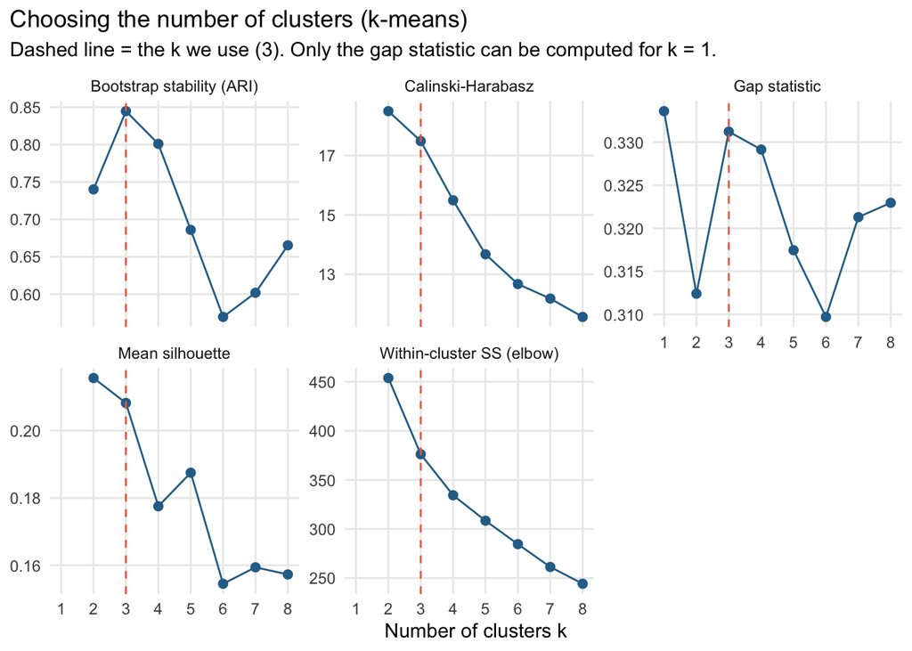

```r
p_k <- criteria |>
  full_join(gap_tab |> select(k, gap), by = "k") |>          # the gap statistic also has k = 1
  select(k, `Within-cluster SS (elbow)` = wss, `Mean silhouette` = silhouette,
         `Calinski-Harabasz` = ch, `Gap statistic` = gap, `Bootstrap stability (ARI)` = stability) |>
  pivot_longer(-k) |>
  ggplot(aes(k, value)) +
  geom_line(colour = "#2a6f97") + geom_point(colour = "#2a6f97", size = 2) +
  geom_vline(xintercept = 3, linetype = 2, colour = "#e76f51") +
  facet_wrap(~name, scales = "free_y", ncol = 3) +
  scale_x_continuous(breaks = 1:8) +
  labs(title = "Choosing the number of clusters (k-means)",
       subtitle = "Dashed line = the k we use (3). Only the gap statistic can be computed for k = 1.",
       x = "Number of clusters k", y = NULL)
save_fig(p_k, "fig04_choose_k", dir = paths$fig_rq2, height = 5, width = 8.5)
```

**Observation.** The criteria don’t all point the same way, which is common with real data.

- **Elbow:** WSS falls steadily with no clear bend, so it gives no answer.
- **Silhouette** and **Calinski–Harabasz** are highest at *k* = 2 and only slightly lower at *k* = 3 (silhouette 0.216 vs 0.208).
- **Bootstrap stability** is clearly highest at *k* = 3 (0.84): resampled data reproduce the same three groups most reliably.
- The **gap statistic** chooses *k* = 1. The gap at *k* = 1 (0.334) is as large as at any other *k*, so the districts are not more clustered than random data spread over the same range.

The most important finding is that **the cluster structure is weak**. All silhouette widths are near 0.2 (below the 0.25 usually needed for even “weak” structure), and the gap statistic finds no clear clusters. New Zealand’s districts form a **continuum** of markets, not a few sharply different types, which matches the single cloud in the Step 1 PCA plot. Clustering is still useful here, but as a way to **summarise** the continuum into a few recognisable kinds of market, not as proof of natural types.

**Decision: *k* = 3.** It is the most stable choice, nearly as good as *k* = 2 on silhouette and CH, and more informative than two groups. With *k* ≥ 5, small clusters of 3–4 districts appear and stability drops.

# 5 Hierarchical clustering

## 5.1 How it works

Agglomerative hierarchical clustering starts with every district in its own cluster and repeatedly **merges the two closest clusters** until only one is left. The full history of merges is a tree, the **dendrogram**. Cutting the tree at a height gives a set of clusters; cutting it to leave *k* branches gives *k* clusters. Unlike k-means there are no random starts: the result is the same every time.

The method needs a rule for the distance between two *clusters* (not just two districts). This is the **linkage**, its main parameter:

| Linkage (`method`) | Distance between clusters A and B | Typical result |
| --- | --- | --- |
| `single` | closest pair, one from A and one from B | long chains; outliers left on their own |
| `complete` | farthest pair | compact clusters, sensitive to outliers |
| `average` | average over all pairs | between single and complete |
| `ward.D2` | merge the pair that increases the total within-cluster sum of squares the least | compact, similar-sized clusters; same goal as k-means |

`ward.D2` is the correct form of Ward’s method for Euclidean distances (`ward.D` expects squared distances).

## 5.2 Comparing linkages

The **cophenetic correlation** measures how faithfully a dendrogram keeps the original distances: the correlation between the distance of each pair of districts and the height at which the tree first joins them.

```r
linkages <- c("single", "complete", "average", "ward.D2")
hcs <- map(set_names(linkages), \(m) hclust(D, method = m))
link_tab <- imap_dfr(hcs, function(h, m) {
  cl <- cutree(h, k = 3)
  tibble(linkage = m,
         cophenetic_correlation = cor(cophenetic(h), D),
         cluster_sizes_at_k3 = paste(sort(table(cl), decreasing = TRUE), collapse = " / "),
         silhouette_k3 = mean_silhouette(cl, D))
})
save_tab(link_tab, "t03_linkages", dir = paths$tab_rq2) |> kable(digits = 3, caption = "Four linkages, cut at three clusters")
```

Four linkages, cut at three clusters

| linkage | cophenetic_correlation | cluster_sizes_at_k3 | silhouette_k3 |
| --- | --- | --- | --- |
| single | 0.706 | 64 / 1 / 1 | 0.308 |
| complete | 0.523 | 44 / 20 / 2 | 0.201 |
| average | 0.782 | 62 / 2 / 2 | 0.292 |
| ward.D2 | 0.520 | 34 / 20 / 12 | 0.182 |

**Observation.** The linkage matters far more than the cophenetic correlation suggests.

- **Single and average** linkage have the highest cophenetic correlations, but cut at three clusters they give 64/1/1 and 62/2/2: one huge cluster plus a few outlying districts split off on their own. They describe the tree well but give a useless grouping. This is the “chaining” behaviour of single linkage.
- **Complete** linkage is better, but still leaves a cluster of 2.
- **Ward** gives three clusters of useful size (34/20/12). It is also the only linkage with the same goal as k-means (small within-cluster spread), which makes the two methods directly comparable.

We use Ward’s method for the comparison with k-means.

## 5.3 The Ward dendrogram

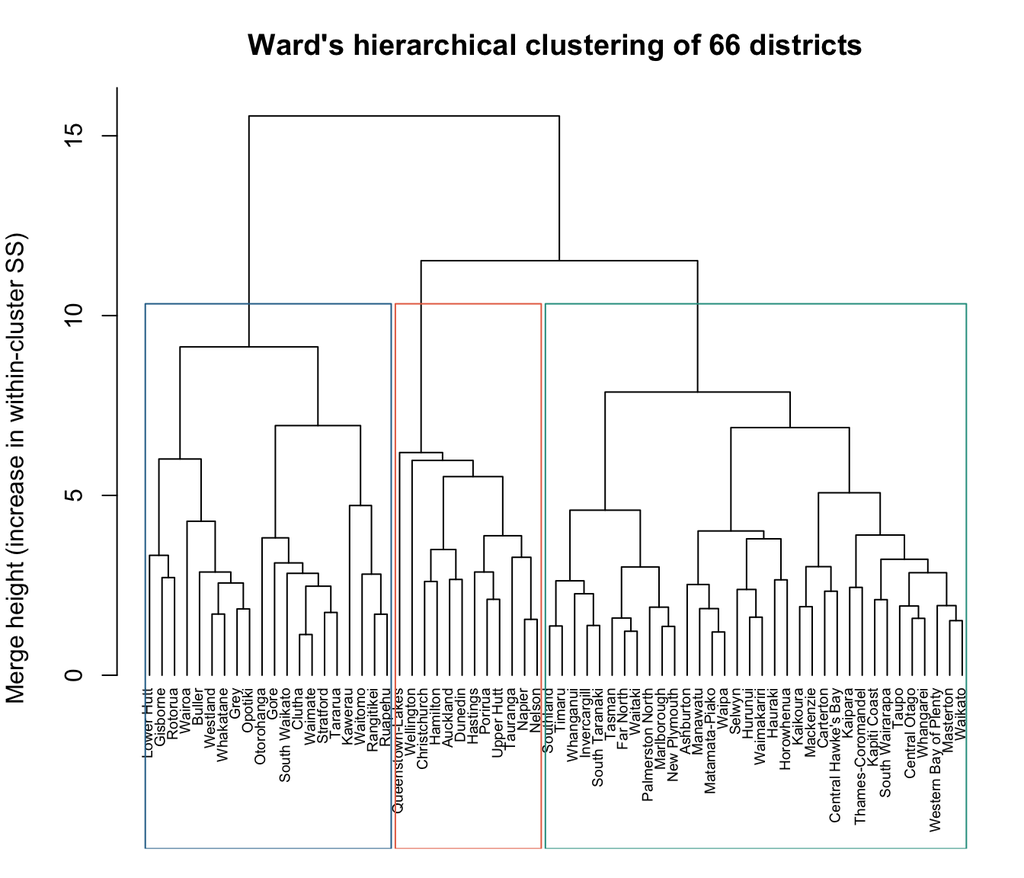

```r
hc <- hcs[["ward.D2"]]
draw_dendro <- function() {
  par(mar = c(1, 4, 3, 1))
  plot(hc, hang = -1, cex = 0.6, main = "Ward's hierarchical clustering of 66 districts",
       sub = "", xlab = "", ylab = "Merge height (increase in within-cluster SS)")
  rect.hclust(hc, k = 3, border = c("#2a6f97", "#e76f51", "#2a9d8f"))
}
png(file.path(paths$fig_rq2, "fig05_dendrogram.png"), width = 11, height = 6, units = "in", res = 200)
draw_dendro(); invisible(dev.off())
draw_dendro()
```

**Observation.** The tree’s first split (the highest merge) separates the slow-building provincial districts (left) from all the rest. The second split separates the cities and dense urban districts (middle) from a large group of growing house-building districts (right). Inside the right-hand branch, a group of southern and western provincial districts (Southland, Timaru, Invercargill, Whanganui, South Taranaki) joins late. These districts sit between the provincial and growing groups, and k-means places some of them differently (below).

The merge heights rise smoothly rather than jumping, so there is no height at which the tree “obviously” should be cut. This is the same weak structure the criteria showed.

## 5.4 Stability of Ward clusters

```r
ward_criteria <- map_dfr(2:6, function(k) {
  cl <- ward_labels(X, k)
  tibble(k, silhouette = mean_silhouette(cl, D), ch = calinski_harabasz(X, cl),
         stability = mean(boot_stability(X, \(x) ward_labels(x, k), B = 100)))
})
kable(ward_criteria, digits = 3, caption = "Ward's method: criteria by number of clusters")
```

Ward’s method: criteria by number of clusters

| k | silhouette | ch | stability |
| --- | --- | --- | --- |
| 2 | 0.212 | 16.677 | 0.587 |
| 3 | 0.182 | 14.843 | 0.589 |
| 4 | 0.182 | 13.299 | 0.571 |
| 5 | 0.112 | 12.205 | 0.500 |
| 6 | 0.112 | 11.334 | 0.469 |

**Observation.** Ward’s clusters are noticeably **less stable** than k-means’ (about 0.59 vs 0.84 at *k* = 3). This is a known weakness of hierarchical clustering: once two districts are merged, the merge is never undone, so a small change in the data early on changes everything above it. k-means can move a district between clusters at every step.

# 6 Do k-means and Ward agree?

The **adjusted Rand index (ARI)** compares two clusterings of the same items. It counts the pairs of districts that both methods put together (or both keep apart), and corrects for the agreement expected by chance. ARI = 1 means identical groupings, even if the clusters are numbered differently; ARI = 0 means no more agreement than random labels.

```r
set.seed(462)
km3 <- kmeans(X, centers = 3, nstart = 50, iter.max = 100)
cl_km   <- relabel_by_size(km3$cluster)
cl_ward <- relabel_by_size(cutree(hc, k = 3))

table(`k-means` = cl_km, Ward = cl_ward)
```

```
##        Ward
## k-means  1  2  3
##       1 30  0  0
##       2  3 18  0
##       3  1  2 12
```

```r
ari_km_ward <- adjusted_rand(cl_km, cl_ward)
c(ARI = ari_km_ward)
```

```
##       ARI
## 0.7479088
```

```r
tibble(district = short, `k-means` = cl_km, Ward = cl_ward) |>
  filter(`k-means` != Ward) |> kable(caption = "Districts the two methods place differently")
```

Districts the two methods place differently

| district | k-means | Ward |
| --- | --- | --- |
| Gisborne | 3 | 2 |
| Invercargill | 2 | 1 |
| Lower Hutt | 3 | 2 |
| Palmerston North | 3 | 1 |
| South Taranaki | 2 | 1 |
| Whanganui | 2 | 1 |

**Observation.** The two methods agree on most districts (ARI = 0.75). They differ on six districts: Invercargill, South Taranaki and Whanganui (provincial in k-means, house-building in Ward), Palmerston North (urban vs house-building), and Gisborne and Lower Hutt (urban vs provincial). These are the borderline districts: they sit between two clusters in the PCA plot, and both methods are partly right about them.

**Decision.** We use the **k-means clustering with k = 3** as the final grouping. It is more stable under resampling than Ward’s, has the higher silhouette, and k-means directly minimises the within-cluster spread we care about. Ward’s tree is kept as a second view, which shows how the clusters split further.

# 7 The three building markets

## 7.1 Profiles

```r
final <- raw |> mutate(cluster = cl_km, name = short)

profile_vars <- c(vars, "alt_share", "dwellings")
profile <- final |>
  group_by(cluster) |>
  summarise(districts = n(), across(all_of(profile_vars), median), .groups = "drop")
profile |>
  mutate(across(c(apt_share, retire_share, town_share, nonres_share, alt_share), \(x) 100 * x),
         rel_cost = 100 * (exp(rel_cost) - 1), growth = 100 * (exp(growth) - 1), volatility = 100 * volatility) |>
  save_tab("t04_cluster_profiles", dir = paths$tab_rq2) |>
  kable(digits = 1, caption = paste("Median of each feature by cluster, natural units.",
                                    "Shares, cost, growth and volatility in %; dwellings = total over ten years"))
```

Median of each feature by cluster, natural units. Shares, cost, growth and volatility in %; dwellings = total over ten years

| cluster | districts | apt_share | retire_share | town_share | dwell_per_1000 | growth | volatility | rel_cost | house_m2 | nonres_share | alt_share | dwellings |
| --- | --- | --- | --- | --- | --- | --- | --- | --- | --- | --- | --- | --- |
| 1 | 30 | 0.4 | 5.8 | 9.3 | 7.5 | -3.1 | 26.5 | -4.2 | 191.7 | 22.1 | 14.1 | 2618.5 |
| 2 | 21 | 0.2 | 0.0 | 12.0 | 3.1 | 21.4 | 35.6 | -8.3 | 176.9 | 39.3 | 23.2 | 487.0 |
| 3 | 15 | 4.5 | 5.6 | 33.4 | 4.9 | 11.1 | 26.9 | 4.9 | 183.4 | 33.6 | 14.6 | 4705.0 |

**Observation.** The three clusters differ in clear and interpretable ways:

1. **House-building districts** (30 districts). The highest building intensity (median 7.5 new dwellings per 1,000 residents a year), the biggest houses (192 m²), almost all stand-alone houses plus retirement villages, the least volatile building, a small non-residential share, and slightly cheaper than average (−4%). These are commuter belts around the cities (Selwyn, Waimakariri, Waikato, Waipa), lifestyle and retirement areas (Thames-Coromandel, Kāpiti Coast, Tasman, Central Otago), and growing rural service towns (Ashburton, Marlborough).
2. **Slow provincial districts** (21 districts). The lowest building intensity (3.1 per 1,000), almost no apartments or retirement units (their townhouse share, 12%, is similar to the house-building districts’ 9%), the most volatile building, the largest non-residential share (39%), the smallest houses (177 m²) and the cheapest construction (−8%). They are small (a median of under 500 new dwellings in ten years). Building did pick up in 2021–2026 (+21%), but from a low base.
3. **Urban medium-density markets** (15 districts). A third of new dwellings are townhouses, flats or units, and some are apartments (4.5%). Construction is the dearest (+5% vs other districts), and they are the largest markets. Twelve of the 15 are city councils, plus Queenstown-Lakes, Gisborne and Hastings.

```r
# names chosen from the profiles above (cluster 1 = largest)
cluster_names <- c("House-building districts", "Slow provincial districts", "Urban medium-density")
final <- final |> mutate(market = factor(cluster_names[cluster], levels = cluster_names))
final |> group_by(market) |>
  summarise(districts = n(), members = paste(sort(name), collapse = ", ")) |>
  save_tab("t05_cluster_members", dir = paths$tab_rq2) |>
  kable(caption = "Members of each cluster")
```

Members of each cluster

| market | districts | members |
| --- | --- | --- |
| House-building districts | 30 | Ashburton, Carterton, Central Hawke’s Bay, Central Otago, Far North, Hauraki, Horowhenua, Hurunui, Kaikoura, Kaipara, Kapiti Coast, Mackenzie, Manawatu, Marlborough, Masterton, Matamata-Piako, New Ply… |
| Slow provincial districts | 21 | Buller, Clutha, Gore, Grey, Invercargill, Kawerau, Opotiki, Otorohanga, Rangitikei, Rotorua, Ruapehu, South Taranaki, South Waikato, Stratford, Tararua, Waimate, Wairoa, Waitomo, Westland, Whakatane, … |
| Urban medium-density | 15 | Auckland, Christchurch, Dunedin, Gisborne, Hamilton, Hastings, Lower Hutt, Napier, Nelson, Palmerston North, Porirua, Queenstown-Lakes, Tauranga, Upper Hutt, Wellington |

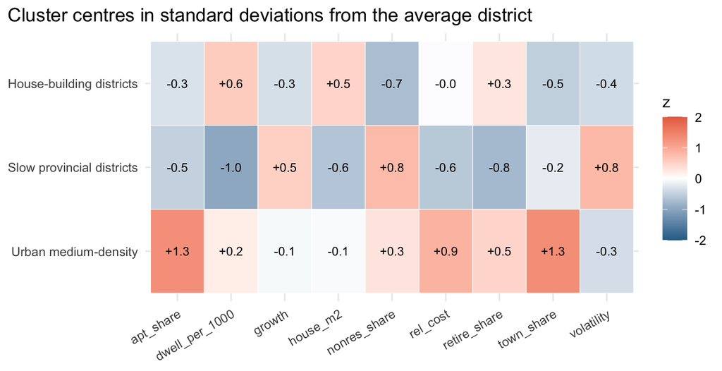

```r
centres <- as_tibble(X) |> mutate(cluster = cl_km) |>
  group_by(cluster) |> summarise(across(everything(), mean)) |>
  pivot_longer(-cluster, names_to = "feature", values_to = "z")
p_centres <- ggplot(centres |> mutate(market = factor(cluster_names[cluster], levels = rev(cluster_names))),
                    aes(feature, market, fill = z)) +
  geom_tile(colour = "white") +
  geom_text(aes(label = sprintf("%+.1f", z)), size = 3) +
  scale_fill_gradient2(low = "#2a6f97", mid = "white", high = "#e76f51", midpoint = 0, limits = c(-2, 2),
                       oob = scales::squish) +
  labs(title = "Cluster centres in standard deviations from the average district",
       x = NULL, y = NULL, fill = "z") +
  theme(axis.text.x = element_text(angle = 30, hjust = 1))
save_fig(p_centres, "fig06_cluster_centres", dir = paths$fig_rq2, height = 3.6, width = 8)
```

## 7.2 Where the clusters sit

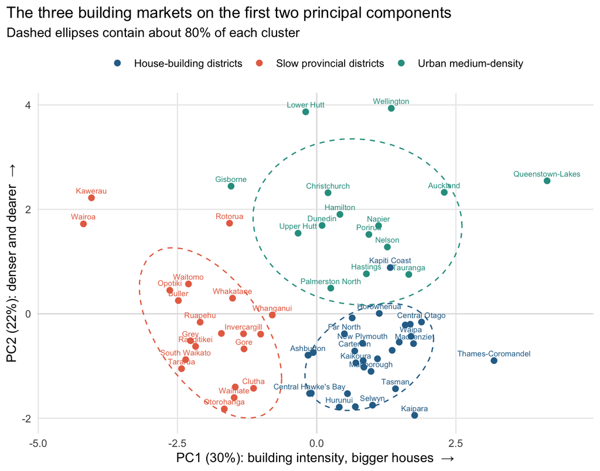

```r
pca <- prcomp(X)
pv <- pca$sdev^2 / sum(pca$sdev^2)
pca_df <- as_tibble(pca$x[, 1:2]) |> mutate(name = short, market = final$market)
market_cols <- set_names(c("#2a6f97", "#e76f51", "#2a9d8f"), cluster_names)

p_pca <- ggplot(pca_df, aes(PC1, PC2, colour = market)) +
  geom_hline(yintercept = 0, colour = "grey88") + geom_vline(xintercept = 0, colour = "grey88") +
  stat_ellipse(level = 0.8, linetype = 2, show.legend = FALSE) +
  geom_point(size = 2) +
  geom_text(aes(label = name), size = 2.3, vjust = -0.8, check_overlap = TRUE, show.legend = FALSE) +
  scale_colour_manual(values = market_cols) +
  scale_x_continuous(expand = expansion(mult = 0.1)) +
  labs(title = "The three building markets on the first two principal components",
       subtitle = "Dashed ellipses contain about 80% of each cluster",
       x = sprintf("PC1 (%.0f%%): building intensity, bigger houses  →", 100 * pv[1]),
       y = sprintf("PC2 (%.0f%%): denser and dearer  →", 100 * pv[2]), colour = NULL) +
  theme(legend.position = "top")
save_fig(p_pca, "fig07_clusters_pca", dir = paths$fig_rq2, height = 5.5, width = 8)
```

## 7.3 How well does each district fit?

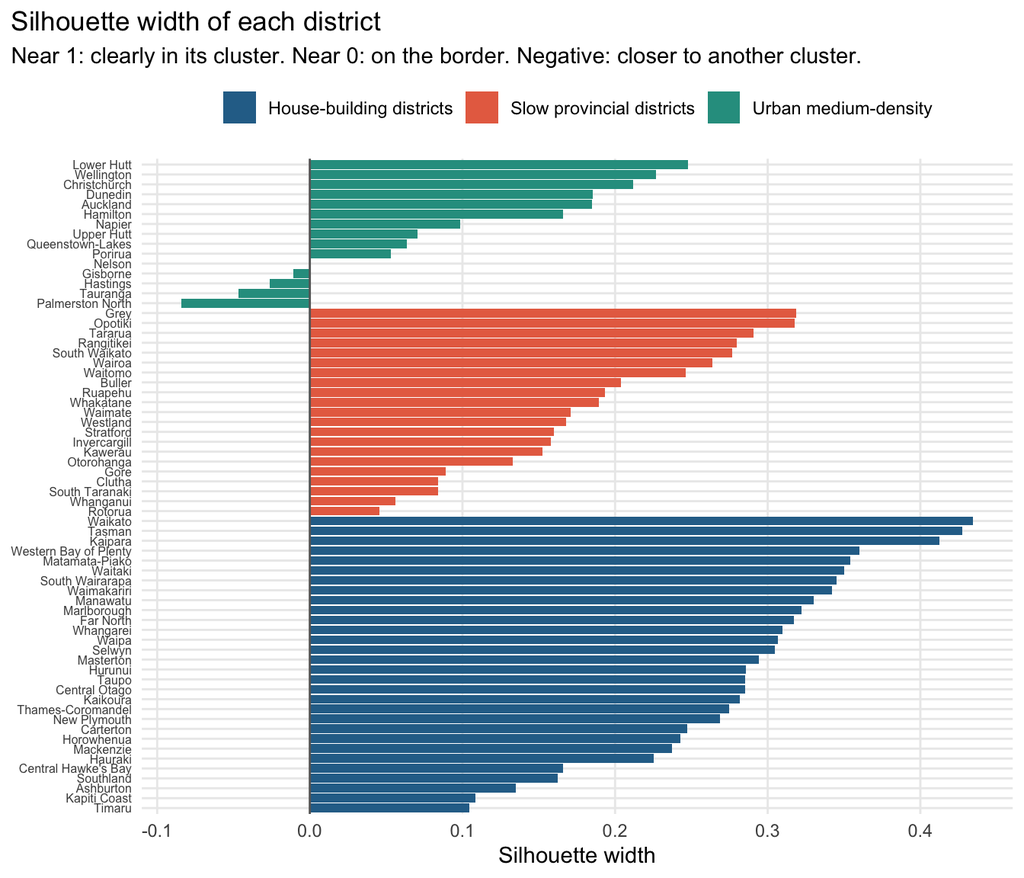

```r
sil <- silhouette(cl_km, D)
sil_df <- tibble(name = short, market = final$market, width = sil[, "sil_width"],
                 neighbour = cluster_names[sil[, "neighbor"]]) |>
  arrange(market, width) |>
  mutate(name = factor(name, levels = name))
p_sil <- ggplot(sil_df, aes(width, name, fill = market)) +
  geom_col() +
  geom_vline(xintercept = 0, colour = "grey40") +
  scale_fill_manual(values = market_cols) +
  labs(title = "Silhouette width of each district",
       subtitle = "Near 1: clearly in its cluster. Near 0: on the border. Negative: closer to another cluster.",
       x = "Silhouette width", y = NULL, fill = NULL) +
  theme(axis.text.y = element_text(size = 6), legend.position = "top")
save_fig(p_sil, "fig08_silhouette", dir = paths$fig_rq2, height = 6, width = 7)
```

```r
sil_df |> group_by(market) |> summarise(mean_width = mean(width), negative = sum(width < 0)) |> kable(digits = 3)
```

| market | mean_width | negative |
| --- | --- | --- |
| House-building districts | 0.284 | 0 |
| Slow provincial districts | 0.185 | 0 |
| Urban medium-density | 0.089 | 4 |

```r
sil_df |> filter(width < 0) |> select(name, market, width, neighbour) |> kable(digits = 3,
  caption = "Districts closer, on average, to another cluster")
```

Districts closer, on average, to another cluster

| name | market | width | neighbour |
| --- | --- | --- | --- |
| Palmerston North | Urban medium-density | -0.084 | House-building districts |
| Tauranga | Urban medium-density | -0.047 | House-building districts |
| Hastings | Urban medium-density | -0.026 | House-building districts |
| Gisborne | Urban medium-density | -0.011 | Slow provincial districts |

**Observation.** The house-building cluster is the most coherent (mean silhouette about 0.28), and no district in it is closer to another cluster. The urban cluster is the loosest (about 0.09). Four of its members have negative widths: Palmerston North, Tauranga and Hastings are, on average, closer to the house-building districts, and Gisborne is closer to the provincial ones. The urban cluster is held together mainly by its townhouse and apartment shares. Apart from that, its members are quite different from each other (compare Wellington and Queenstown).

# 8 Which features separate the clusters? (ANOVA)

**One-way analysis of variance (ANOVA)** tests whether the mean of a variable differs between groups. It splits the variation of the feature into a part *between* clusters and a part *within* clusters:

$$F = \frac{\text{between-cluster variance} / (k-1)}{\text{within-cluster
variance} / (n-k)}$$

A large *F* means the cluster means are far apart compared with the spread inside each cluster. We also report **η² (eta squared)**, the share of the feature’s variance explained by the clusters (between SS ÷ total SS), which is easier to compare across features than *F*.

**Caution.** The clusters were *made* to differ on these features, so the p-values are not honest tests: they will be small even for random data. We use *F* and η² only to **rank** the features by how much they separate the clusters.

```r
tf <- rq2$transformed
anova_tab <- map_dfr(vars, function(v) {
  fit <- aov(tf[[v]] ~ factor(cl_km))
  s <- summary(fit)[[1]]
  tibble(feature = v, F = s[1, "F value"], p_value = s[1, "Pr(>F)"],
         eta_squared = s[1, "Sum Sq"] / sum(s[, "Sum Sq"]))
}) |> arrange(desc(eta_squared))
save_tab(anova_tab, "t06_anova", dir = paths$tab_rq2) |>
  kable(digits = 3, caption = "One-way ANOVA of each (transformed) feature on the three clusters")
```

One-way ANOVA of each (transformed) feature on the three clusters

| feature | F | p_value | eta_squared |
| --- | --- | --- | --- |
| town_share | 37.206 | 0.000 | 0.542 |
| apt_share | 32.843 | 0.000 | 0.510 |
| dwell_per_1000 | 27.636 | 0.000 | 0.467 |
| nonres_share | 24.671 | 0.000 | 0.439 |
| volatility | 13.791 | 0.000 | 0.304 |
| rel_cost | 12.888 | 0.000 | 0.290 |
| retire_share | 12.176 | 0.000 | 0.279 |
| house_m2 | 9.620 | 0.000 | 0.234 |
| growth | 5.414 | 0.007 | 0.147 |

**Observation.** Townhouse share, apartment share, building intensity and non-residential share separate the clusters most: each has η² of about 0.44–0.54, so the clusters explain about half of their variation. Cost, volatility, retirement share and house size come next (η² 0.23–0.30). Growth separates the clusters least (η² ≈ 0.15), so districts that are growing fast are found in all three markets. All p-values are tiny, but as noted, that is guaranteed by how clusters are formed and is not evidence on its own.

# 9 How robust are the clusters?

## 9.1 Leaving out one feature at a time

If the clusters reflect real differences, removing a single feature should not change them much. We re-run k-means (k = 3) nine times, each time without one feature, and compare with the final clustering (ARI).

```r
loo <- map_dfr(vars, function(v) {
  set.seed(462)
  cl <- kmeans(X[, setdiff(vars, v)], centers = 3, nstart = 50, iter.max = 100)$cluster
  tibble(left_out = v, ARI_with_final = adjusted_rand(cl_km, cl))
}) |> arrange(ARI_with_final)
save_tab(loo, "t07_leave_one_feature_out", dir = paths$tab_rq2) |>
  kable(digits = 3, caption = "Agreement with the final clusters when one feature is left out")
```

Agreement with the final clusters when one feature is left out

| left_out | ARI_with_final |
| --- | --- |
| nonres_share | 0.552 |
| house_m2 | 0.789 |
| apt_share | 0.803 |
| volatility | 0.861 |
| growth | 0.914 |
| town_share | 0.921 |
| rel_cost | 0.964 |
| retire_share | 1.000 |
| dwell_per_1000 | 1.000 |

## 9.2 A finer split: four clusters

```r
set.seed(462)
cl_k4 <- relabel_by_size(kmeans(X, centers = 4, nstart = 50, iter.max = 100)$cluster)
table(`k = 3` = final$market, `k = 4` = cl_k4)
```

```
##                            k = 4
## k = 3                        1  2  3  4
##   House-building districts  27  3  0  0
##   Slow provincial districts  0 12  0  9
##   Urban medium-density       0  0 13  2
```

```r
final |> mutate(k4 = cl_k4) |> group_by(k4) |>
  summarise(districts = n(), members = paste(sort(name), collapse = ", ")) |> kable()
```

| k4 | districts | members |
| --- | --- | --- |
| 1 | 27 | Carterton, Central Hawke’s Bay, Central Otago, Far North, Hauraki, Horowhenua, Hurunui, Kaikoura, Kaipara, Kapiti Coast, Mackenzie, Manawatu, Marlborough, Masterton, Matamata-Piako, New Plymouth, Selw… |
| 2 | 15 | Ashburton, Clutha, Gore, Grey, Invercargill, Otorohanga, Rangitikei, South Taranaki, South Waikato, Southland, Stratford, Tararua, Timaru, Waimate, Whanganui |
| 3 | 13 | Auckland, Christchurch, Dunedin, Hamilton, Hastings, Lower Hutt, Napier, Nelson, Palmerston North, Porirua, Queenstown-Lakes, Tauranga, Wellington |
| 4 | 11 | Buller, Gisborne, Kawerau, Opotiki, Rotorua, Ruapehu, Upper Hutt, Wairoa, Waitomo, Westland, Whakatane |

**Observation.** With four clusters, the urban and house-building groups stay almost unchanged. The **slow provincial** cluster splits in two:

- southern and central provincial districts (Clutha, Gore, Invercargill, Tararua, South Waikato and others), joined by Ashburton, Southland and Timaru from the house-building group. These are steady farming-service economies;
- a group of small, volatile districts, mostly in the central and eastern North Island and on the West Coast (Kawerau, Ōpōtiki, Wairoa, Waitomo, Ruapehu, Whakatane, Gisborne, Rotorua, Buller, Westland). These have the most volatile building and the smallest houses.

Upper Hutt also joins this second group, which makes no geographic or economic sense. It is a sign that the four-cluster solution is less reliable (lower stability, above). The split is a useful finer description but we keep three clusters as the main result.

# 10 Clusters, geography and cost

```r
table(final$market, final$island)
```

```
##
##                             North South
##   House-building districts     18    12
##   Slow provincial districts    14     7
##   Urban medium-density         11     4
```

```r
final |> group_by(market) |>
  summarise(cities = sum(is_city), median_dwellings = median(dwellings),
            median_rel_cost_pct = 100 * (exp(median(rel_cost)) - 1),
            regions = n_distinct(region)) |>
  kable(digits = 1)
```

| market | cities | median_dwellings | median_rel_cost_pct | regions |
| --- | --- | --- | --- | --- |
| House-building districts | 0 | 2618.5 | -4.2 | 12 |
| Slow provincial districts | 1 | 487.0 | -8.3 | 9 |
| Urban medium-density | 12 | 4705.0 | 4.9 | 10 |

**Observation.** Every cluster contains districts from both islands and from 9–12 of the 16 regions. The markets are **not** just geography. A Canterbury commuter district (Selwyn) has more in common with a Waikato one (Waipa) than with Christchurch, its neighbour. Construction cost differs between clusters (urban +5%, house-building −4%, provincial −8% relative to other districts). This agrees with RQ1, where denser, busier markets were dearer.

# 11 Answer to RQ2

**Question.** What kinds of building markets does New Zealand have?

**Answer.** Grouping the 66 districts on nine features of their building over 2016–2026 gives three kinds of market:

| Market | Districts | What characterises it | Examples |
| --- | --- | --- | --- |
| House-building districts | 30 | Most new dwellings per resident, large stand-alone houses and retirement villages, steady building, slightly cheap | Selwyn, Waimakariri, Waipa, Tasman, Kāpiti Coast, Thames-Coromandel |
| Slow provincial districts | 21 | Little building for their population, volatile, more commercial building, small houses, cheapest | Gore, Clutha, Wairoa, Ōpōtiki, Grey, South Waikato |
| Urban medium-density markets | 15 | Many townhouses and some apartments, largest markets, dearest | Auckland, Wellington, Christchurch, Hamilton, Queenstown-Lakes |

**How sure are we?**

- k-means and Ward’s hierarchical clustering agree on 60 of the 66 districts (ARI 0.75), and k-means reproduces the same clusters in resampled data (stability about 0.84).
- But the separation is **weak** (mean silhouette about 0.2), and the gap statistic finds no evidence of clusters beyond a continuum. The three markets are a useful summary of a continuous range, not sharply separate types. Districts near the borders (Palmerston North, Tauranga, Hastings, Gisborne, Invercargill) could reasonably be placed in either neighbouring cluster.
- The clusters are driven mostly by dwelling type (townhouse and apartment shares), building intensity and the share of non-residential building, and they are not just geographic.

**Limitations.** The result depends on the choice of features and on the ten-year window. Volatility is partly a small-district effect, although leaving it out changes little. With 66 districts, small changes in the data can move border districts between clusters.

# 12 Save

```r
dir.create(paths$models_rq2, showWarnings = FALSE, recursive = TRUE)
membership <- final |> select(ta, name, region, island, market, cluster) |>
  mutate(silhouette = sil[, "sil_width"], ward_cluster = cl_ward, k4_cluster = cl_k4)
write_csv(membership, file.path(paths$tab_rq2, "t08_district_membership.csv"))
saveRDS(list(kmeans = km3, hclust_ward = hc, membership = membership, centres_z = km3$centers,
             scaling = list(center = attr(X, "scaled:center"), scale = attr(X, "scaled:scale")),
             vars = vars, cluster_names = cluster_names),
        file.path(paths$models_rq2, "rq2_clusters.rds"))
list.files(paths$models_rq2)
```

```
## [1] "rq2_clusters.rds"
```

# 13 Appendix: helper functions

This notebook uses helper functions from `R/utils_data.R` and `R/utils_cluster.R`, printed here so the document is complete on its own.

```r
# =============================================================================
# R/utils_data.R
# Shared helpers for reading and reshaping Stats NZ data.
# Source this from any Rmd after the project root has been set:
#   source(file.path(proj_root, "R", "utils_data.R"))
# =============================================================================

suppressPackageStartupMessages({
  library(data.table)
  library(tidyverse)
})

# ---- Paths (all relative to the project root) -------------------------------
paths <- list(
  raw_extracted = "data/raw/extracted",
  raw_cgpi      = "data/raw/external/cgpi",
  reference     = "data/reference",
  processed     = "data/processed",
  fig_rq1       = "outputs/figures/rq1",
  tab_rq1       = "outputs/tables/rq1",
  fig_rq2       = "outputs/figures/rq2",
  tab_rq2       = "outputs/tables/rq2"
)

# ---- Reading Stats NZ "Infoshare" long-format CSVs --------------------------
# Every Infoshare file has one row per (series x period). We read only the
# columns that carry information and give them short working names.
#
# Notes
# * `Period` MUST be read as text: as a number, "2025.10" becomes 2025.1,
#   which is indistinguishable from January.
# * integer64 is turned off so that large dollar values come back as doubles
#   (integer64 silently overflows on division).
read_infoshare <- function(file,
                           dir = paths$raw_extracted,
                           keep_status = FALSE) {
  cols <- c("Series_reference", "Period", "Data_value",
            "Series_title_1", "Series_title_2",
            "Series_title_3", "Series_title_4", "Series_title_5")
  if (keep_status) cols <- c(cols, "Status")

  dt <- fread(file.path(dir, file),
              select      = cols,
              colClasses  = list(character = "Period"),
              integer64   = "double",
              na.strings  = c("", "NA"),
              showProgress = FALSE)

  as_tibble(dt) |>
    rename(series  = Series_reference,
           period  = Period,
           value   = Data_value,
           area    = Series_title_1,
           btype   = Series_title_2,
           work    = Series_title_3,
           measure = Series_title_4,
           adjust  = Series_title_5)   # Actual / Seasonally adjusted / Trend (regional files only)
}

# ---- Period helpers ----------------------------------------------------------
# "YYYY.MM" -> integer year / month / calendar quarter
period_year    <- function(p) as.integer(substr(p, 1, 4))
period_month   <- function(p) as.integer(substr(p, 6, 7))
month_quarter  <- function(m) (m - 1L) %/% 3L + 1L

# Label like "2019Q3"
yq_label <- function(year, quarter) paste0(year, "Q", quarter)

# Sequential quarter index (1990Q1 = 1) - handy as a numeric time trend
yq_index <- function(year, quarter) (year - 1990L) * 4L + quarter

# ---- GST ---------------------------------------------------------------------
# Consent values are GST-inclusive. GST was 12.5% from 1 Jul 1989 to
# 30 Sep 2010 and 15% from 1 Oct 2010. Every month in our data is >= 1990,
# so only these two rates apply. Quarter boundaries line up with the change
# (2010Q4 starts on 1 Oct 2010), so a quarter-level rule is exact.
gst_rate <- function(year, quarter) {
  if_else(yq_index(year, quarter) >= yq_index(2010L, 4L), 0.15, 0.125)
}

# ---- Small display helpers ---------------------------------------------------
fmt_int <- function(x) format(round(x), big.mark = ",", scientific = FALSE)
fmt_dol <- function(x) paste0("$", fmt_int(x))
fmt_pct <- function(x, d = 1) paste0(format(round(100 * x, d), nsmall = d), "%")

# ---- Figures -----------------------------------------------------------------
theme_set(theme_minimal(base_size = 11) +
            theme(plot.title.position = "plot",
                  panel.grid.minor = element_blank()))

# Save a ggplot as PNG (for the report) and return it (so it also shows in the Rmd)
save_fig <- function(p, name, dir = paths$fig_rq1, width = 7, height = 4.2) {
  dir.create(dir, recursive = TRUE, showWarnings = FALSE)
  ggsave(file.path(dir, paste0(name, ".png")), p,
         width = width, height = height, dpi = 200, bg = "white")
  p
}

# Save a table as CSV (for the report) and return it
save_tab <- function(df, name, dir = paths$tab_rq1) {
  dir.create(dir, recursive = TRUE, showWarnings = FALSE)
  write_csv(df, file.path(dir, paste0(name, ".csv")))
  df
}
```

```r
# =============================================================================
# R/utils_cluster.R
# Shared helpers for clustering (RQ2). Source AFTER utils_data.R:
#   source(file.path(proj_root, "R", "utils_data.R"))
#   source(file.path(proj_root, "R", "utils_cluster.R"))
# Needs the 'cluster' package (installed with R).
# =============================================================================

paths$models_rq2 <- "outputs/models/rq2"

# ---- Variance inflation factor ----------------------------------------------
# VIF_j = 1 / (1 - R2_j), where R2_j comes from regressing feature j on all the
# other features. 1 = unrelated to the others; above about 5 = largely repeated
# by the others. Returns Inf when a feature is an exact combination of others.
vif_table <- function(df) {
  vars <- names(df)
  tibble(feature = vars,
         vif = map_dbl(vars, function(v) {
           r2 <- summary(lm(reformulate(setdiff(vars, v), response = v), data = df))$r.squared
           if (r2 > 1 - 1e-10) Inf else 1 / (1 - r2)
         }))
}

# ---- Adjusted Rand index -----------------------------------------------------
# Agreement between two partitions of the same items, corrected for chance:
# 1 = identical (labels may be numbered differently), 0 = no better than random.
adjusted_rand <- function(a, b) {
  tab <- table(a, b)
  n   <- sum(tab)
  sum_ij <- sum(choose(tab, 2))
  sum_a  <- sum(choose(rowSums(tab), 2))
  sum_b  <- sum(choose(colSums(tab), 2))
  expected <- sum_a * sum_b / choose(n, 2)
  (sum_ij - expected) / ((sum_a + sum_b) / 2 - expected)
}

# ---- Calinski-Harabasz index --------------------------------------------------
# (between-cluster variance / (k - 1)) / (within-cluster variance / (n - k)).
# Higher = tighter, better separated clusters. Same idea as an ANOVA F ratio.
calinski_harabasz <- function(X, cl) {
  X <- as.matrix(X); k <- length(unique(cl)); n <- nrow(X)
  total  <- sum(scale(X, scale = FALSE)^2)
  within <- sum(sapply(unique(cl), function(g) sum(scale(X[cl == g, , drop = FALSE], scale = FALSE)^2)))
  ((total - within) / (k - 1)) / (within / (n - k))
}

# ---- Mean silhouette width -----------------------------------------------------
mean_silhouette <- function(cl, D) mean(cluster::silhouette(cl, D)[, "sil_width"])

# ---- Bootstrap stability -------------------------------------------------------
# How reproducible is a clustering? Repeat B times: draw a bootstrap sample of
# the rows, re-cluster it, and compare with the clustering of the full data on
# the rows that were drawn (adjusted Rand index). Average over the B repeats.
#   cluster_fun(X) must return a vector of cluster labels for the rows of X.
boot_stability <- function(X, cluster_fun, B = 100, seed = 462) {
  set.seed(seed)
  full <- cluster_fun(X)
  map_dbl(seq_len(B), function(b) {
    rows <- sort(unique(sample(nrow(X), replace = TRUE)))
    adjusted_rand(full[rows], cluster_fun(X[rows, , drop = FALSE]))
  })
}

# ---- k-means and Ward wrappers with fixed settings ----------------------------
kmeans_labels <- function(X, k, nstart = 50) kmeans(X, centers = k, nstart = nstart, iter.max = 100)$cluster
ward_labels   <- function(X, k) cutree(hclust(dist(X), method = "ward.D2"), k = k)

# ---- Relabel clusters by size --------------------------------------------------
# k-means numbers clusters arbitrarily (and differently with another seed).
# Renumber so cluster 1 is the largest, which keeps tables and colours stable.
relabel_by_size <- function(cl) {
  ord <- names(sort(table(cl), decreasing = TRUE))
  as.integer(factor(cl, levels = ord))
}
```